# ProyectoFinal

Aaron Sanchez

5 de junio de 2015

# Proyecto Final

## Aarón Ch. Sánchez Padilla

## Exploración inicial de los datos

```r
# Este bloque debería de tener la bandera de echo a FALSE

library(dplyr)
library(tidyr)
library(ggplot2)
library(lubridate)
library(stringr)
library(ROCR)
library(tm)
library(Rstem)
library(RCurl)
library(bitops)
library(digest)
library(rjson)
library(cluster)
library(wordcloud)

library(e1071)
library(gmodels)
library(stylo)
source("utils.r")
```

```r
# Este bloque debería de tener la bandera de echo a FALSE

# NOTA: Todos los bloques de este documento, tienen eval a FALSE, se debería de eliminar

# Cargamos el dataset

ds.path <- "ufos.rds"

ds.name <- "ufo" # Nombre de nuestro conjunto de datos, e.g. algas, german

ds  <- readRDS(ds.path) # Leemos el dataset, usando readRDS (ya que ya lo tenemos en disco debido a nuestro EDA)
   # Hay que utilizar el data set al que no se le han removido las observaciones NAs
   # Lo guardamos en la variable ds para hacer más genérico los pasos.

ds <- tbl_df(ds) # Para obtener un print mejorado
```

# Introducción

## Variables

Date/Time: es un timestamp del cuando ocurrió avistamiento. City: la ciudad en donde ocurrió el avistamiento. State: la abreviación del estado en donde ocurrió el avistamiento. Shape: la forma del ovni observado. Duration: el tiempo estimado de la duración del avistamiento. Summary: un breve resumen que explique en qué consistió el avistamiento. Poster: fecha del registro del avistamiento. Report: narración del evento ocurrido

# Estructura General

```r
ds
```

```
## Source: local data frame [97,148 x 8]
##
##      Date...Time              City State     Shape       Duration
## 1  4/23/15 12:00         Rock Hill    SC Rectangle     10 minutes
## 2  4/23/15 02:30          Mt. Orab    OH    Sphere         1 hour
## 3  4/23/15 01:30     Columbia City    IN      Disk     20 minutes
## 4  4/23/15 00:00        Middletown    RI   Unknown 44 Years known
## 5  4/22/15 23:39           Boulder    CO    Circle     10 seconds
## 6  4/22/15 23:30          Richmond    VA    Sphere     12 seconds
## 7  4/22/15 23:00     Mountain Home    ID     Light   5-10 seconds
## 8  4/22/15 23:00 Kalamata (Greece)           Light        2 hours
## 9  4/22/15 22:00  North Ridgeville    OH  Fireball     30 seconds
## 10 4/22/15 22:00      Elizabethton    TN  Cylinder      5 minutes
## ..           ...               ...   ...       ...            ...
## Variables not shown: Summary (chr), Posted (chr), report (fctr)
```

## Tamaño

```r
dim(ds)
```

```
## [1] 97148     8
```

## Columnas

```r
names(ds)
```

```
## [1] "Date...Time" "City"        "State"       "Shape"       "Duration"
## [6] "Summary"     "Posted"      "report"
```

## Estructura

```r
str(ds)
```

```
## Classes 'tbl_df', 'tbl' and 'data.frame':    97148 obs. of  8 variables:
##  $ Date...Time: chr  "4/23/15 12:00" "4/23/15 02:30" "4/23/15 01:30" "4/23/15 00:00" ...
##  $ City       : chr  "Rock Hill" "Mt. Orab" "Columbia City" "Middletown" ...
##  $ State      : chr  "SC" "OH" "IN" "RI" ...
##  $ Shape      : chr  "Rectangle" "Sphere" "Disk" "Unknown" ...
##  $ Duration   : chr  "10 minutes" "1 hour" "20 minutes" "44 Years known" ...
##  $ Summary    : chr  "Big white objects falling from the sky." "The object looked like a star and hovered, moving only a small amount in an hour's time.  ((NUFORC Note:  Planet?  PD))" "Flying saucer with blinking lights that zigzagged." "Satellite Imagery of the course of 44 years." ...
##  $ Posted     : chr  "4/23/15" "4/23/15" "4/23/15" "4/23/15" ...
##  $ report     : Factor w/ 97032 levels "\r\n\r\n","0:00 04/23/08 Newport Oregon High Flying Objects with Red Halo/Haze @ High Speed, No SoundAt approximately midnight I was outsi"| __truncated__,..: 14969 77835 31344 66411 91639 86863 19819 75438 16863 15092 ...
```

## Observaciones

```r
head(ds)
```

```
## Source: local data frame [6 x 8]
##
##     Date...Time          City State     Shape       Duration
## 1 4/23/15 12:00     Rock Hill    SC Rectangle     10 minutes
## 2 4/23/15 02:30      Mt. Orab    OH    Sphere         1 hour
## 3 4/23/15 01:30 Columbia City    IN      Disk     20 minutes
## 4 4/23/15 00:00    Middletown    RI   Unknown 44 Years known
## 5 4/22/15 23:39       Boulder    CO    Circle     10 seconds
## 6 4/22/15 23:30      Richmond    VA    Sphere     12 seconds
## Variables not shown: Summary (chr), Posted (chr), report (fctr)
```

```r
tail(ds)
```

```
## Source: local data frame [6 x 8]
##
##      Date...Time                                      City State    Shape
## 1  6/30/90 21:00                                  Carlisle    NY Fireball
## 2 12/11/62 21:00 Lulworth, Dorsetshire (near) (UK/England)    NA       NA
## 3   2/1/15 03:00                       Truckee/Cisco Grove    CA Cylinder
## 4  4/14/61 08:00                        Nurnburg (Germany)    NA Cylinder
## 5  6/30/00 00:00                       Myers Spring Canyon    TX   Circle
## 6   3/1/15 19:55                                   Wahiawa    HI    Flash
## Variables not shown: Duration (chr), Summary (chr), Posted (chr), report
##   (fctr)
```

# Sumario Estadístico

```r
summary(ds)
```

[output not shown]

# Limpieza de metadatos

```r
# Usaremos la función que hiciste de ejercicio
names(ds) <- normalizarNombres(names(ds))
```

Además de normalizar los nombres de variables, este es el lugar para poner nombres que tengan significado como que la columna que tenga datos de fecha, se llame `fecha` o `date`.

```r
names(ds)
```

```
## [1] "date...time" "city"        "state"       "shape"       "duration"
## [6] "summary"     "posted"      "report"
```

# Ajuste de formatos

Las clases de las variables son

```r
sapply(ds, class)
```

```
## date...time        city       state       shape    duration     summary
## "character" "character" "character" "character" "character" "character"
##      posted      report
## "character"    "factor"
```

En esta sección arreglamos los formatos de los datos. Un ejemplo típico son las fechas.

Otros problemas con variables son: categóricas/numéricas que no lo son, booleanas que no lo son, ordenar variables nominales, reetiquetar las variables categóricas, etc.

Para arreglar las fechas, utiliza el paquete `lubridate`.

El formato de fechas debe de ser `YMD` y si es `timestamp` debe de serlo hasta la precisión que den los datos, no más, no menos.

```r
# Ejemplo hipotético
library(lubridate)
ds$posted <- ymd(as.character(ds$posted))
ds2<-ds
ds <- ds %>%
  mutate(date = as.Date(ds$date...time,format ='%m/%d/%y'),
         city = city,
         state = state,
         shape = shape) %>%
  dplyr::select(date,city,state,shape)
```

Así quedan las variables corregidas:

```r
sapply(ds, class)
```

```
##        date        city       state       shape
##      "Date" "character" "character" "character"
```

## Conexión con postgres

```r
library(RPostgreSQL)
library(sqldf)
drv <- dbDriver("PostgreSQL")
## Base de datos
con <- dbConnect(drv, dbname="ufo-db", user="aaronsapa")
con <- dbConnect(PostgreSQL(), user= "aaronsapa", dbname="ufo-db")
## query
ufo<- dbReadTable(con,"ufo")
```

# ¿Primer avistamiento en cada estado?

```r
first_views <- dbGetQuery(con,"SELECT state, date  FROM ufo GROUP BY state ORDER BY date")
```

```
##    state       date
## 1     LA 1969-01-01
## 2     NV 1969-01-01
## 3     PA 1969-01-01
## 4     FL 1969-01-04
## 5     MT 1969-01-15
## 6     IN 1969-02-15
## 7     IL 1969-03-01
## 8     NE 1969-03-01
## 9     NJ 1969-03-01
## 10    OK 1969-03-15
```

# ¿Primer avistamiento de cada forma?

```r
first_shapes<- dbGetQuery(con, "SELECT shape, MIN(date) FROM ufo GROUP BY shape ORDER BY date")
```

```
##        shape       date
## 1      Other 1969-01-01
## 2   Triangle 1969-01-01
## 3    Unknown 1969-01-01
## 4       Oval 1969-01-04
## 5      Light 1969-01-15
## 6  Rectangle 1969-01-15
## 7     Sphere 1969-01-15
## 8       Disk 1969-01-20
## 9      Cigar 1969-02-12
## 10     Cross 1969-03-15
```

# ¿Promedio de entre avistamientos, por mes, por año? ¿Por estado?

# por mes

```r
prom_m<-dbGetQuery(con,"select month(date), count, avg(cuenta) prom_mes
from(select count(date) count,extract(year from date) anio,
extract(month from date) mes, state
from ufo
group by extract(year from date),
extract (month from date), state) as base
group by (mes)
order by (mes)")
```

[output not shown]

# por año

```r
prom_m<-dbGetQuery(con,"select year(date),count, avg(count) prom_anio
from(select count(date) count from ufo
group by extract(year from date) anio,
extract (month from date), state) as base
group by (anio)
order by (anio)")
```

```
## Source: local data frame [10 x 3]
##
##    year(date) count prom_anio
## 1        1969   183  3.893617
## 2        1970   174  3.702128
## 3        1971   142  3.021277
## 4        1972   202  4.297872
## 5        1973   264  5.617021
## 6        1974   309  6.574468
## 7        1975   366  7.787234
## 8        1976   327  6.957447
## 9        1977   304  6.468085
## 10       1978   386  8.212766
```

# por estado

```r
prom_s<-dbGetQuery(con,"select state, count, avg(cuenta) prom_estado
from(select count(date) count,extract(year from date) anio,
extract(month from date) mes, state
from ufo
group by extract(year from date),
extract (month from date), state) as base
group by (state)
order by (promedio_estado) desc
limit 10;")
```

```
## Source: local data frame [10 x 3]
##
##    state count prom_estado
## 1     CA 11212   160.17143
## 2     FL  5135    73.35714
## 3     WA  5016    71.65714
## 4     TX  4369    62.41429
## 5     NY  3845    54.92857
## 6     AZ  3234    46.20000
## 7     PA  3150    45.00000
## 8     IL  3060    43.71429
## 9     OH  2913    41.61429
## 10    MI  2454    35.05714
```

# ¿Cuál estado tiene mayor varianza?

[output not shown]

# ¿Existen olas temporales?

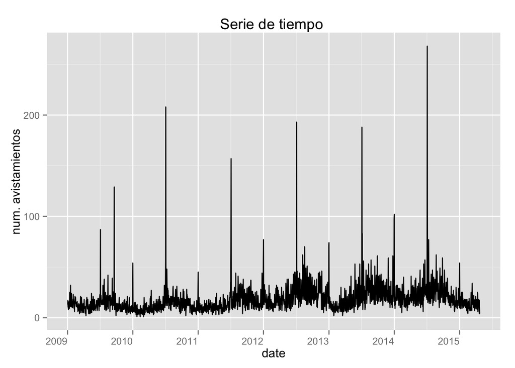

# ¿Narrativas parecidas?

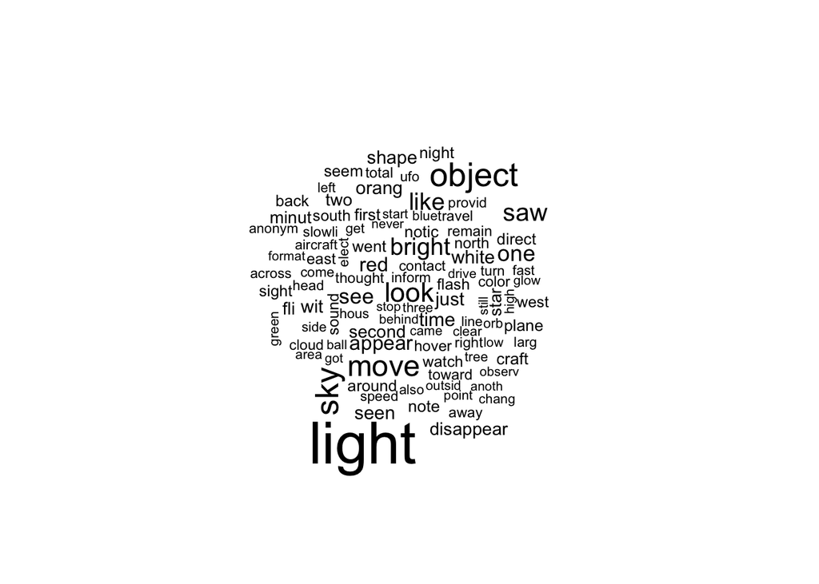

```r
ufo <-ds2[1:6000,]
ufo$report <- tolower(ufo$report)

corpus <- Corpus(VectorSource(ufo$report), list(language ="en_US"))
corpus <- tm_map(corpus, removeWords, stopwords(kind = "en"))
corpus <- tm_map(corpus, removeWords, stylo.pronouns(language = "English"))
corpus <- tm_map(corpus , removePunctuation)
corpus <- tm_map(corpus, stemDocument, language = "english",lazy=TRUE)
corpus <- tm_map(corpus, stripWhitespace)
corpus <- tm_map(corpus, content_transformer(tolower))
corpus <- tm_map(corpus, removeNumbers)

corpus <- tm_map(corpus, PlainTextDocument)
termDocMatrix <- TermDocumentMatrix(corpus, control = list(wordLengths = c(1, Inf)))
freq.terms <- findFreqTerms(termDocMatrix, lowfreq=116)
term.freq <- rowSums(as.matrix(termDocMatrix))
term.freq <- subset(term.freq, term.freq >=5)
dfTermfq <- data.frame(term = names(term.freq), freq = term.freq)
wordcloud(corpus, max.words = 100,  scale = c(3, 0.5))
```

# ¿Cómo está relacionado con las características sociales?

```r
df.educacion <- read.csv(file="educacion.csv", header = TRUE, sep = ",")
tbl_df(df.educacion)
```

```
## Source: local data frame [53 x 2]
##
##    Post.Office.Abbreviation ANSI.Code
## 1                                  NA
## 2                        US  25.80656
## 3                        AL  20.20258
## 4                        AK  25.75807
## 5                        AZ  24.21990
## 6                        AR  17.53028
## 7                        CA  27.99629
## 8                        CO  33.41028
## 9                        CT  33.03135
## 10                       DE  25.95908
## ..                      ...       ...
```

```r
colnames(df.educacion)[1] <- "state"
colnames(df.educacion)[2] <- "Bachelor"
str(df.educacion)
```

```
## 'data.frame':    53 obs. of  2 variables:
##  $ state   : Factor w/ 53 levels "","AK","AL","AR",..: 1 46 3 2 5 4 6 7 8 10 ...
##  $ Bachelor: num  NA 25.8 20.2 25.8 24.2 ...
```

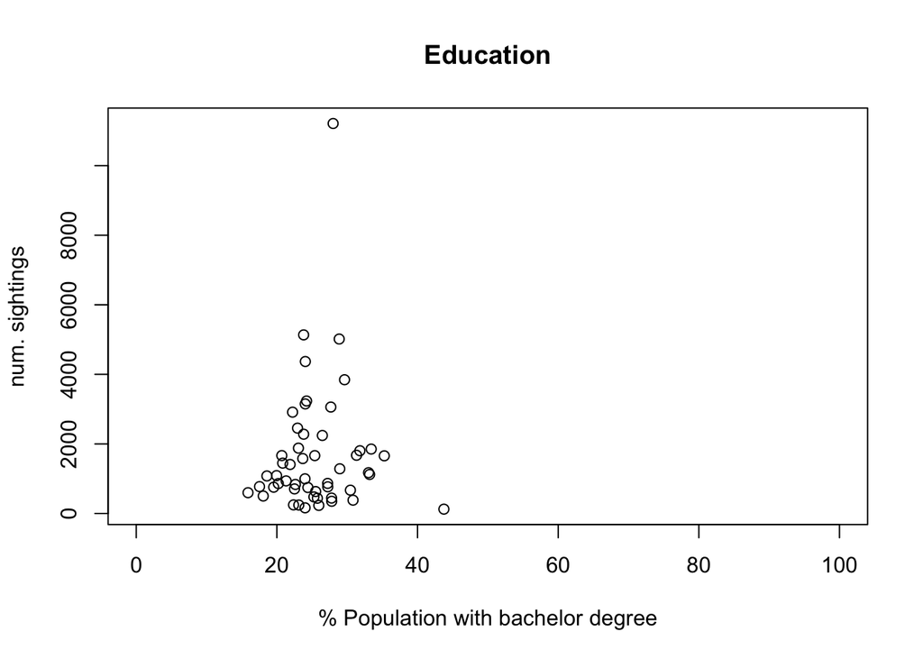

```r
ds.aux <-subset(ds, grepl("[A-Z][A-Z]", state))
prom_s <- ds.aux %>%
  filter(state != "") %>%
  group_by(state) %>%
  dplyr::summarise(count = n())
ds.social<-merge(x=prom_s,y=df.educacion, by = "state", all.y = TRUE)
library(stats)
ds.social<-ds.social[complete.cases(ds.social),]
plot(count~Bachelor, xlim = c(0, 100), ylab = 'num. sightings', xlab = '% Population with bachelor degree', main = 'Education', data = ds.social)
with(ds.social, text(state, labels = row.names(ds.social[1]), pos = 4))
```